# How to use Markdown

John Little

2020-03-20

## My first markdown note

###### tags: `test` `hello world`

> This is a note. See (to the right) how the note appears as a highlight? You can use the `>` markup your any text. Add your own text.

## Second level header

For more Markdown help see 1. Help > Markdown quick reference 2. Help > Cheatsheets > R Markdown cheat sheets 3. [R Markdown](http://rmarkdown.rstudio.com) Notebooks

### Step 1: Change the title and add a tag

Favorite fruits - orange - nectarine  
- apple - grape

Checkbox - [x] Create my first HackMD note (this one!) - [ ] Change its title - [ ] Add a tag

### Step 2: Write something in Markdown

Write something else in this basic paragraph **Everyone can structure documents with Markdown.** *Most people love* markdown. Some people are less enthusiastic. Add your own text in this paragraph.[^1] You can manage footnotes, citations, and bibliographies. Learn more about citations and bibliographies in the Cheatsheet `(RStudio IDE > Help > Cheatsheets > R Markdown cheat sheet)`[^2] There is more than one kind of markup for footnotes. I like the above style. However, you can also do use this style.[^3]

- **Bold**
- *Italic*
- Super<sup>script</sup>
- Sub<sub>script</sub>
- Strikethrough

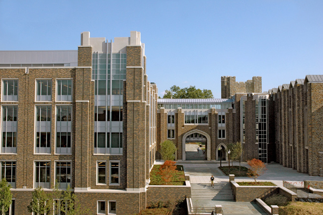

Library Building

## BONUS: More cool markdown tricks

Table 1

| Resources | Acronym |
| --- | --- |
| [R learning series](https://rfun.library.duke.edu) | Rfun |
| [Center for Data & Visualization Sciences](https://library.duke.edu/data/) | CDVS |
| [RStudio Primers](https://Rstudio.cloud/learn/primers) | No Acronym |

Table 2

| apples | red | 6 |
| --- | --- | --- |
| grapes | green | 32 |
| oranges and nanners | orange/yellow | 2 |

- LaTeX for formulas

$$x = {-b \pm \sqrt{b^2-4ac} \over 2a}$$

- Inline equations

The formula for the Area of a circle is … $A = \pi*r^{2}$

- Code block with color and line numbers：

```r
starwars %>%
  filter(hair_color == "brown")
```

`monospacing and inline code` can also be used

[^1]: Inlines notes don’t have to pick an identifier.
[^2]: [Browse all the RStudio Cheatsheets](https://rstudio.com/resources/cheatsheets/)
[^3]: Test, [Link](https://google.com).